# Practical Machine Learning assignment

## Summary

Various accelerometer measurements (about 50 features remain after preprocessing of about 160 total features) are used to predict the outcome of a weight lifting excercise. The outcomes are classified according to their “correctness” of how the excercise movements have been performed. There are 5 outcome classes, of roughly equal ocurrence, so no skewness in stratification needs to be taken into account.

A random forest approach is chosen for its robustness, with k-fold cross validation to counter the tendency of decision trees to be overfitted. Over 99% accuracy is achieved (vs just 50% on a single decison tree).

## Preprocessing

After loading the data, removing timestamps, row index, columns with near zero variance, and columns with over 95% NA values:

```r
library(ggplot2)
library(lattice)
library(caret)
library(rattle)
dRaw     <- read.csv("../pml-training.csv")
testing  <- read.csv("../pml-testing.csv")

# removing row number (X) and timestamps (not doing time series analyses here)
rc <- c("X","user_name", "raw_timestamp_part_1", "raw_timestamp_part_2", "cvtd_timestamp")
rc1 <- which(colnames(dRaw) %in% rc)
dclean <- dRaw[,-rc1]

# removing features with near zero variance
rc2 <- nearZeroVar(dclean)
dclean <- dclean[,-rc2]

# removing features with mostly (95%) NA (not addressed by nearZeroVar)
rc3 <- which(colSums(is.na(dclean)) / nrow(dclean) > 0.95)
dclean <- dclean[,-rc3]

set.seed(12345)
intrain <- createDataPartition(dclean$classe, p = .70, list = FALSE)
dtrain <- dclean[intrain, ]
dtest  <- dclean[-intrain, ]
```

This leaves about 50 features for the classification task. The data set contains about 20’000 records, a 70/30 train / test split is chosen, so that there is sufficient amount of test data to estimate the classifier accuracy.

## Analyses

Random Forest is chosen as classification approach as it is relatively robust with respect to outliers and correlated features. As an example, a single decision tree is trained and plotted below, achieving about 50% accuracy:

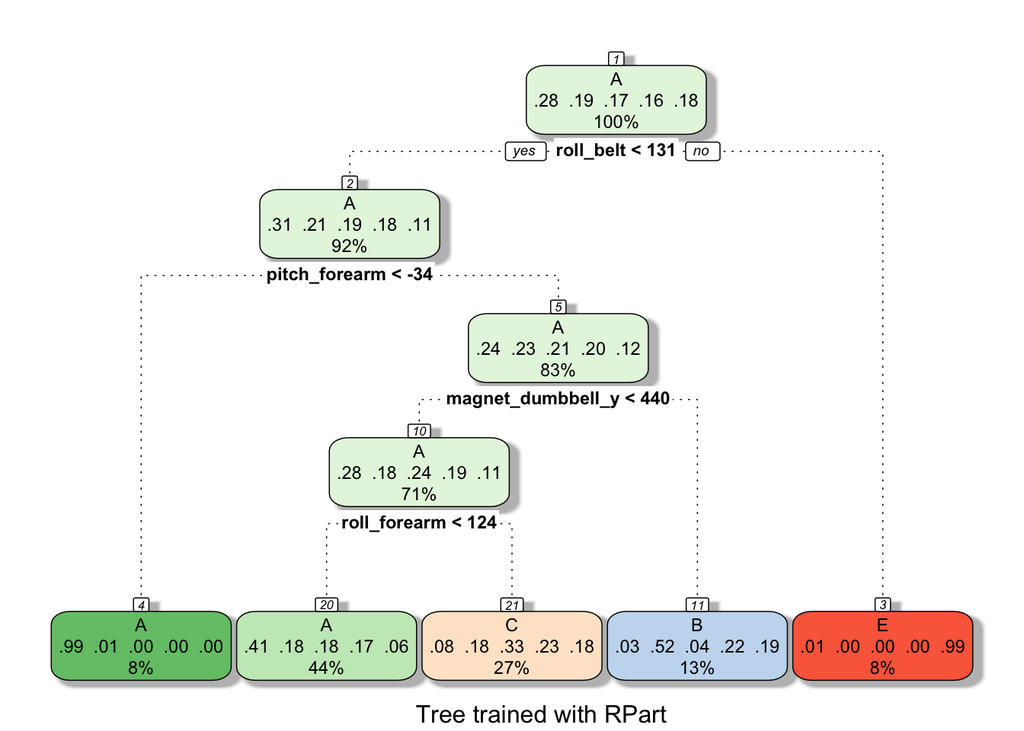

```r
tree <- train(classe ~., data=dtrain, method="rpart")
fancyRpartPlot(tree$finalModel, caption="Tree trained with RPart")
```

```r
tree
```

```
## CART
##
## 13737 samples
##    53 predictor
##     5 classes: 'A', 'B', 'C', 'D', 'E'
##
## No pre-processing
## Resampling: Bootstrapped (25 reps)
## Summary of sample sizes: 13737, 13737, 13737, 13737, 13737, 13737, ...
## Resampling results across tuning parameters:
##
##   cp          Accuracy   Kappa
##   0.03839894  0.5449173  0.41297459
##   0.06092971  0.3964246  0.17619664
##   0.11595972  0.3354682  0.07862684
##
## Accuracy was used to select the optimal model using the largest value.
## The final value used for the model was cp = 0.03839894.
```

Moving on to a Randon Forest, here using 5-fold cross-validation (being mindful of computation time):

```r
param <- trainControl(method="cv", 5)
mod <- train(classe ~ ., data=dtrain, method="rf", trControl=param, ntree=200)
mod
```

```
## Random Forest
##
## 13737 samples
##    53 predictor
##     5 classes: 'A', 'B', 'C', 'D', 'E'
##
## No pre-processing
## Resampling: Cross-Validated (5 fold)
## Summary of sample sizes: 10990, 10989, 10991, 10990, 10988
## Resampling results across tuning parameters:
##
##   mtry  Accuracy   Kappa
##    2    0.9942491  0.9927249
##   27    0.9973068  0.9965932
##   53    0.9945406  0.9930940
##
## Accuracy was used to select the optimal model using the largest value.
## The final value used for the model was mtry = 27.
```

As can be seen from the table above, the accuracy of the optimal model is 99.73%. Given the large data set and k-fold cross-validation, we should expect a similar outcome with the final test set. And indeed, as can be seen below with the test set the accuracy is even slightly higher at 99.9%, and the lower 95% confidence interval boundary on the accuracy is 99.78%.

```r
pred <- predict(mod, dtest)
confusionMatrix(dtest$classe, pred)
```

```
## Confusion Matrix and Statistics
##
##           Reference
## Prediction    A    B    C    D    E
##          A 1674    0    0    0    0
##          B    1 1138    0    0    0
##          C    0    2 1024    0    0
##          D    0    0    2  961    1
##          E    0    0    0    0 1082
##
## Overall Statistics
##
##                Accuracy : 0.999
##                  95% CI : (0.9978, 0.9996)
##     No Information Rate : 0.2846
##     P-Value [Acc > NIR] : < 2.2e-16
##
##                   Kappa : 0.9987
##
##  Mcnemar's Test P-Value : NA
##
## Statistics by Class:
##
##                      Class: A Class: B Class: C Class: D Class: E
## Sensitivity            0.9994   0.9982   0.9981   1.0000   0.9991
## Specificity            1.0000   0.9998   0.9996   0.9994   1.0000
## Pos Pred Value         1.0000   0.9991   0.9981   0.9969   1.0000
## Neg Pred Value         0.9998   0.9996   0.9996   1.0000   0.9998
## Prevalence             0.2846   0.1937   0.1743   0.1633   0.1840
## Detection Rate         0.2845   0.1934   0.1740   0.1633   0.1839
## Detection Prevalence   0.2845   0.1935   0.1743   0.1638   0.1839
## Balanced Accuracy      0.9997   0.9990   0.9988   0.9997   0.9995
```